# TP2 MRR

Noah KWA MOUTOME - Victor TAN

2023-10-31

# IV. Cookies Study

```r
cookies_data <- read.csv("cookies.csv")
dim(cookies_data)
```

```
## [1]  32 701
```

We see that there are 700 co-variables. We can assume that some of them are less important than the others. To see this, let’s do a Ridge regression and look at the coefficient of each co-variables.

```r
library(glmnet)
```

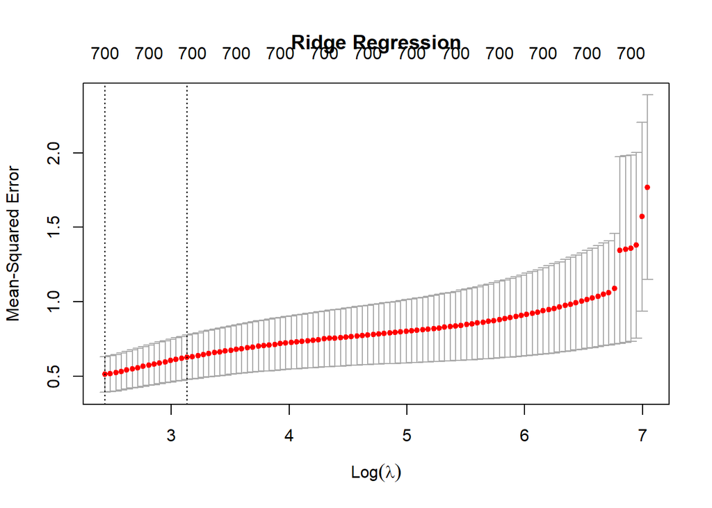

```r
y <- cookies_data[, 1]
X <- cookies_data[, -1]

cv_ridge_model <- cv.glmnet(as.matrix(X), y, alpha=0, standardize = TRUE)
plot(cv_ridge_model, main="Ridge Regression")
```

```r
print(cv_ridge_model)
```

```
##
## Call:  cv.glmnet(x = as.matrix(X), y = y, alpha = 0, standardize = TRUE)
##
## Measure: Mean-Squared Error
##
##     Lambda Index Measure     SE Nonzero
## min  11.42   100  0.5114 0.1197     700
## 1se  22.95    85  0.6251 0.1492     700
```

```r
best_lambda <- cv_ridge_model$lambda.min
best_lambda_ridge_model <- best_lambda
print(paste("Best lambda :", best_lambda))
```

```
## [1] "Best lambda : 11.4243191334971"
```

We can also plot the Regularization Path.

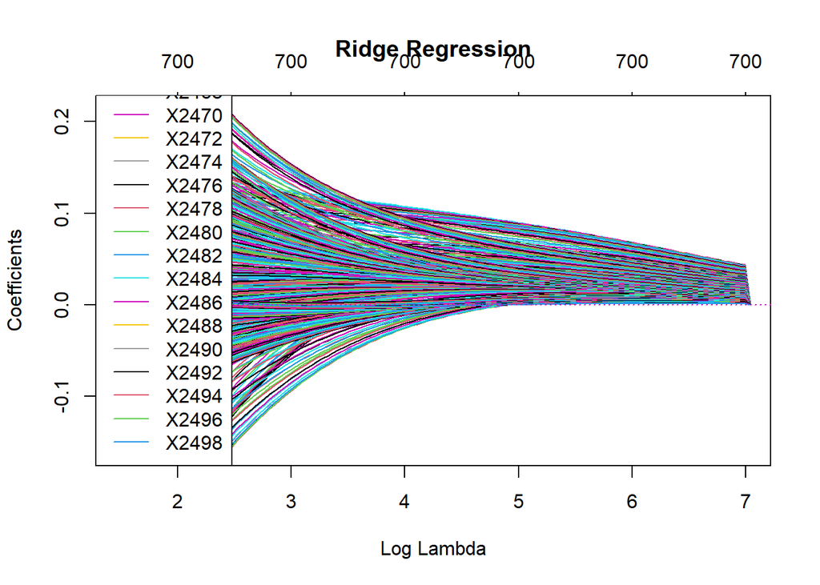

Now let’s take a look at the coefficients of the best model we’ve managed to get.

```r
final_ridge_model <- glmnet(as.matrix(X), y, alpha=0, lambda=best_lambda)

abs_coef <- abs(coef(final_ridge_model)[-1])
```

```
## [1] 2.232542e-05
```

```
## [1] "Number of value higher than 10^-1 :  178"
```

```
## [1] "Number of value higher than 10^-2 :  629"
```

```
## [1] "Number of value higher than 10^-3 :  693"
```

```
## [1] "Number of value higher than 10^-4 :  699"
```

We can see that the majority of the coefficients are lower than $10^{-1}$. Then, we could think that a lot of our co-variables are useless to predict the target variable. (We scaled the data when doing the Ridge regression)